# Bellabeat Case Study

## Introduction and background

Bellabeat specializes in producing advanced technology products designed specifically for women’s health needs.

The objective of this case study is to examine usage data of smart devices, with the aim of obtaining a better understanding of how customers utilize these devices and identifying patterns that can be leveraged to shape Bellabeat’s marketing approach

### Stakeholders: Bellabeat Team

*Urška Sršen*: Bellabeat’s cofounder and Chief Creative Officer *Sando Mur*: Mathematician and Bellabeat’s cofounder; key member of the Bellabeat executive team *Bellabeat marketing analytics team*

## Ask Phase

*Business task:* Analyze smart device usage data in order to gain insight into how consumers use non-Bellabeat smart devices. Then apply these insights and trends into Bellabeat’s customers and marketing strategy.

## Prepare Phase

For this case study we will use the dataset [FitBit Fitness Tracker Data](https://www.kaggle.com/datasets/arashnic/fitbit) made available by Mobius.

The dataset contains 18 different Excel documents tracking different variables. Data is organized in a long format since the consumer ID value repeats itself in the first column.

### Licensing, privacy and accessibility

By checking the metadata of our dataset, we can verify that it is indeed open-source. The creator of the dataset has relinquished all copyright and related rights to the work worldwide, thus dedicating it to the public domain. This allows for the free copying, modification, distribution, and performance of the work, including for commercial purposes, without requiring prior permission.

## Process phase

I will use the RStudio tool for this case study due to it’s capacity for data cleaning and preparation, statistical analysis and visualization.

### Loading packages and libraries

```r
install.packages('tidyverse')
install.packages('ggpubr')
install.packages('car')
install.packages("knitr")
library(tidyverse)
```

```r
library(lubridate)
library(dplyr)
library(ggplot2)
library(tidyr)
```

### Loading CSV files

```r
Activity <- read.csv("dailyActivity_merged.csv")
Calories <- read.csv("dailyCalories_merged.csv")
Steps <- read.csv ("dailySteps_merged.csv")
Sleep <- read.csv ("sleepDay_merged.csv")
Intensities <- read.csv ("dailyIntensities_merged.csv")
Hourly_intensities <- read.csv ('hourlyIntensities_merged.csv')
```

### Exploring a few key tables

Let’s take a look at some of the key tables within the dataset using the head() and View () functions.

```r
head(Activity)
```

```
##           Id ActivityDate TotalSteps TotalDistance TrackerDistance
## 1 1503960366    4/12/2016      13162          8.50            8.50
## 2 1503960366    4/13/2016      10735          6.97            6.97
## 3 1503960366    4/14/2016      10460          6.74            6.74
## 4 1503960366    4/15/2016       9762          6.28            6.28
## 5 1503960366    4/16/2016      12669          8.16            8.16
## 6 1503960366    4/17/2016       9705          6.48            6.48
##   LoggedActivitiesDistance VeryActiveDistance ModeratelyActiveDistance
## 1                        0               1.88                     0.55
## 2                        0               1.57                     0.69
## 3                        0               2.44                     0.40
## 4                        0               2.14                     1.26
## 5                        0               2.71                     0.41
## 6                        0               3.19                     0.78
##   LightActiveDistance SedentaryActiveDistance VeryActiveMinutes
## 1                6.06                       0                25
## 2                4.71                       0                21
## 3                3.91                       0                30
## 4                2.83                       0                29
## 5                5.04                       0                36
## 6                2.51                       0                38
##   FairlyActiveMinutes LightlyActiveMinutes SedentaryMinutes Calories
## 1                  13                  328              728     1985
## 2                  19                  217              776     1797
## 3                  11                  181             1218     1776
## 4                  34                  209              726     1745
## 5                  10                  221              773     1863
## 6                  20                  164              539     1728
```

```r
head(Calories)
```

```
##           Id ActivityDay Calories
## 1 1503960366   4/12/2016     1985
## 2 1503960366   4/13/2016     1797
## 3 1503960366   4/14/2016     1776
## 4 1503960366   4/15/2016     1745
## 5 1503960366   4/16/2016     1863
## 6 1503960366   4/17/2016     1728
```

```r
head(Steps)
```

```
##           Id ActivityDay StepTotal
## 1 1503960366   4/12/2016     13162
## 2 1503960366   4/13/2016     10735
## 3 1503960366   4/14/2016     10460
## 4 1503960366   4/15/2016      9762
## 5 1503960366   4/16/2016     12669
## 6 1503960366   4/17/2016      9705
```

```r
head(Sleep)
```

```
##           Id              SleepDay TotalSleepRecords TotalMinutesAsleep
## 1 1503960366 4/12/2016 12:00:00 AM                 1                327
## 2 1503960366 4/13/2016 12:00:00 AM                 2                384
## 3 1503960366 4/15/2016 12:00:00 AM                 1                412
## 4 1503960366 4/16/2016 12:00:00 AM                 2                340
## 5 1503960366 4/17/2016 12:00:00 AM                 1                700
## 6 1503960366 4/19/2016 12:00:00 AM                 1                304
##   TotalTimeInBed
## 1            346
## 2            407
## 3            442
## 4            367
## 5            712
## 6            320
```

### *Identify all the columns in the different data frames.*

```r
colnames(Activity)
```

```
##  [1] "Id"                       "ActivityDate"
##  [3] "TotalSteps"               "TotalDistance"
##  [5] "TrackerDistance"          "LoggedActivitiesDistance"
##  [7] "VeryActiveDistance"       "ModeratelyActiveDistance"
##  [9] "LightActiveDistance"      "SedentaryActiveDistance"
## [11] "VeryActiveMinutes"        "FairlyActiveMinutes"
## [13] "LightlyActiveMinutes"     "SedentaryMinutes"
## [15] "Calories"
```

```r
colnames(Calories)
```

```
## [1] "Id"          "ActivityDay" "Calories"
```

```r
colnames(Steps)
```

```
## [1] "Id"          "ActivityDay" "StepTotal"
```

```r
colnames(Sleep)
```

```
## [1] "Id"                 "SleepDay"           "TotalSleepRecords"
## [4] "TotalMinutesAsleep" "TotalTimeInBed"
```

```r
colnames(Intensities)
```

```
##  [1] "Id"                       "ActivityDay"
##  [3] "SedentaryMinutes"         "LightlyActiveMinutes"
##  [5] "FairlyActiveMinutes"      "VeryActiveMinutes"
##  [7] "SedentaryActiveDistance"  "LightActiveDistance"
##  [9] "ModeratelyActiveDistance" "VeryActiveDistance"
```

Note that both ‘Activity’ and ‘Sleep’ datasets have the ‘Id’ field - this can be used to merge the datasets.

```r
Activity_and_Sleep <- merge(Activity, Sleep, by = 'Id')
glimpse(Activity_and_Sleep)
```

```
## Rows: 12,441
## Columns: 19
## $ Id                       <dbl> 1503960366, 1503960366, 1503960366, 150396036…
## $ ActivityDate             <chr> "5/7/2016", "5/7/2016", "5/7/2016", "5/7/2016…
## $ TotalSteps               <int> 11992, 11992, 11992, 11992, 11992, 11992, 119…
## $ TotalDistance            <dbl> 7.71, 7.71, 7.71, 7.71, 7.71, 7.71, 7.71, 7.7…
## $ TrackerDistance          <dbl> 7.71, 7.71, 7.71, 7.71, 7.71, 7.71, 7.71, 7.7…
## $ LoggedActivitiesDistance <dbl> 0, 0, 0, 0, 0, 0, 0, 0, 0, 0, 0, 0, 0, 0, 0, …
## $ VeryActiveDistance       <dbl> 2.46, 2.46, 2.46, 2.46, 2.46, 2.46, 2.46, 2.4…
## $ ModeratelyActiveDistance <dbl> 2.12, 2.12, 2.12, 2.12, 2.12, 2.12, 2.12, 2.1…
## $ LightActiveDistance      <dbl> 3.13, 3.13, 3.13, 3.13, 3.13, 3.13, 3.13, 3.1…
## $ SedentaryActiveDistance  <dbl> 0, 0, 0, 0, 0, 0, 0, 0, 0, 0, 0, 0, 0, 0, 0, …
## $ VeryActiveMinutes        <int> 37, 37, 37, 37, 37, 37, 37, 37, 37, 37, 37, 3…
## $ FairlyActiveMinutes      <int> 46, 46, 46, 46, 46, 46, 46, 46, 46, 46, 46, 4…
## $ LightlyActiveMinutes     <int> 175, 175, 175, 175, 175, 175, 175, 175, 175, …
## $ SedentaryMinutes         <int> 833, 833, 833, 833, 833, 833, 833, 833, 833, …
## $ Calories                 <int> 1821, 1821, 1821, 1821, 1821, 1821, 1821, 182…
## $ SleepDay                 <chr> "4/12/2016 12:00:00 AM", "4/13/2016 12:00:00 …
## $ TotalSleepRecords        <int> 1, 2, 1, 2, 1, 1, 1, 1, 1, 1, 1, 1, 1, 1, 1, …
## $ TotalMinutesAsleep       <int> 327, 384, 412, 340, 700, 304, 360, 325, 361, …
## $ TotalTimeInBed           <int> 346, 407, 442, 367, 712, 320, 377, 364, 384, …
```

### Understanding some summary statistics

*How many unique participants are there in each dataframe? It looks like there may be more participants in the daily activity dataset than the sleep dataset.*

```r
n_distinct(Activity$Id)
```

```
## [1] 33
```

```r
n_distinct(Sleep$Id)
```

```
## [1] 24
```

The Activity dataset contains more consumer ID than the Sleep dataset.

*How many observations are there in each dataframe?*

```r
nrow(Activity)
```

```
## [1] 940
```

```r
nrow(Sleep)
```

```
## [1] 413
```

### *Let’s now run some summary statistics about each data frame*

For the daily activity dataframe:

```r
Activity %>%
  select(TotalSteps,
         TotalDistance,
         SedentaryMinutes) %>%
  summary()
```

```
##    TotalSteps    TotalDistance    SedentaryMinutes
##  Min.   :    0   Min.   : 0.000   Min.   :   0.0
##  1st Qu.: 3790   1st Qu.: 2.620   1st Qu.: 729.8
##  Median : 7406   Median : 5.245   Median :1057.5
##  Mean   : 7638   Mean   : 5.490   Mean   : 991.2
##  3rd Qu.:10727   3rd Qu.: 7.713   3rd Qu.:1229.5
##  Max.   :36019   Max.   :28.030   Max.   :1440.0
```

For the sleep dataframe:

```r
Sleep %>%
  select(TotalSleepRecords,
  TotalMinutesAsleep,
  TotalTimeInBed) %>%
  summary()
```

```
##  TotalSleepRecords TotalMinutesAsleep TotalTimeInBed
##  Min.   :1.000     Min.   : 58.0      Min.   : 61.0
##  1st Qu.:1.000     1st Qu.:361.0      1st Qu.:403.0
##  Median :1.000     Median :433.0      Median :463.0
##  Mean   :1.119     Mean   :419.5      Mean   :458.6
##  3rd Qu.:1.000     3rd Qu.:490.0      3rd Qu.:526.0
##  Max.   :3.000     Max.   :796.0      Max.   :961.0
```

# *What does this tell us about how this sample of people’s activities?*

We can see that the average number of steps per days is 7638, lower than the 10K usually steps recommended for a healthy lifestyle.

With regards to the average of sleep hours per night, that figure is close to 7 hours (419 minutes). The recommended amount of sleep hours of an adult is 7 to 9 hours.

Hence our consumers are on the lower band of both recommended number of steps per day and hours of sleep.

### Plotting a few explorations

What’s the relationship between steps taken in a day and burned calories? How could this help inform the customer segments that we can market to?

Let’s examine the following correlations:

### *Daily Steps vs Calories*

[figure not shown]

```r
ggplot(Activity, aes(x = Calories, y = TotalSteps)) +
  geom_point(size = 3, alpha = 0.5) +
  geom_smooth(method = "lm", se = FALSE) +
  labs(x = "Total Steps", y = "Calories", title = "Daily Steps vs Calories") +
  coord_cartesian(xlim = c(0, 5000), ylim = c(0, 30000)) +
  theme_minimal() +
  theme(
    plot.title = element_text(size = 16, face = "bold", hjust = 0.5),
    axis.title = element_text(size = 14),
    panel.grid = element_line(color = "gray", linetype = "dotted")
  )
```

As expected, there is a positive correlation between the number of steps taken per day and the number of burned calories. The higher the physical activity the more calories are burned.

### *Total minutes asleep vs Total time in Bed*

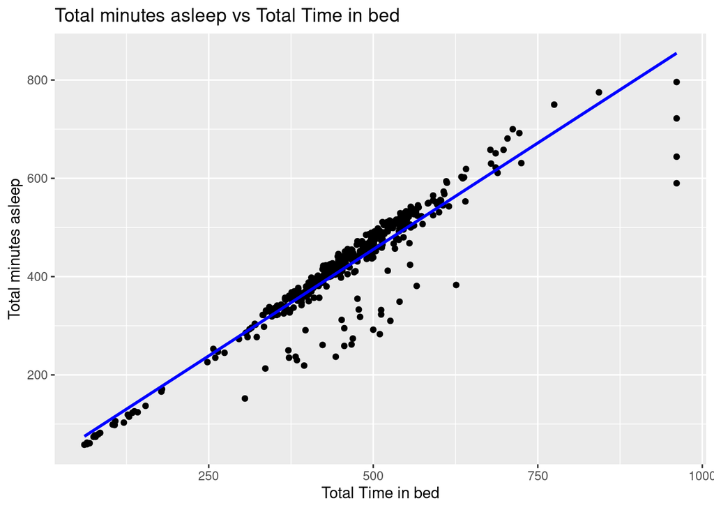

```r
library(ggplot2)

x <- Sleep$`Total Time in bed`
y <- Sleep$`Total minutes asleep`

# create scatter plot
ggplot(data = Sleep, aes(x = TotalTimeInBed, y = TotalMinutesAsleep)) +
  geom_point() +
  geom_smooth(method = "lm", se = FALSE, color = "blue") +  # Add trendline
  xlab("Total Time in bed") +
  ylab("Total minutes asleep") +
  ggtitle("Total minutes asleep vs Total Time in bed")
```

In general, we can see a positive correlation between the two variables.

One suggestion to promote the Bellabeat app would be to recommend to the marketing team to *incorporate notifications to remind users about their sleep time.*

### *Consumers Activity levels*

In the absence of demographic variables in our sample, we aim to classify users based on their activity level using the available data. We can group users into different categories by considering their daily step count. Therefore, we propose to determine the type of users based on their activity level, which can be classified as follows:

*Sedentary: Less than 5,000 steps daily* Low active: About 5,000 to 7,499 steps daily *Somewhat active: About 7,500 to 9,999 steps daily* Active: More than 10,000 steps daily *Highly active: More than 12,500 steps daily

Source: [Medicinenet.com](https://www.medicinenet.com/how_many_steps_a_day_is_considered_active/article.htm)

### Let’s look at the *average steps per user ID:*

```r
daily_average_steps <- Steps %>%
  group_by(Id) %>%
  summarise(mean_daily_steps = mean(StepTotal))


head(daily_average_steps)
```

```
## # A tibble: 6 × 2
##           Id mean_daily_steps
##        <dbl>            <dbl>
## 1 1503960366           12117.
## 2 1624580081            5744.
## 3 1644430081            7283.
## 4 1844505072            2580.
## 5 1927972279             916.
## 6 2022484408           11371.
```

```r
user_activity <- daily_average_steps %>%
  mutate(user_type = case_when(
    mean_daily_steps < 5000 ~ "sedentary",
    mean_daily_steps >= 5000 & mean_daily_steps < 7499 ~ "lightly active",
    mean_daily_steps >= 7500 & mean_daily_steps < 9999 ~ "fairly active",
    mean_daily_steps >= 10000 ~ "active",
    mean_daily_steps >= 12500 ~ "highly active"
  ))

head(user_activity)
```

```
## # A tibble: 6 × 3
##           Id mean_daily_steps user_type
##        <dbl>            <dbl> <chr>
## 1 1503960366           12117. active
## 2 1624580081            5744. lightly active
## 3 1644430081            7283. lightly active
## 4 1844505072            2580. sedentary
## 5 1927972279             916. sedentary
## 6 2022484408           11371. active
```

### *Let’s now convert the above data into percentages:*

```r
library(dplyr)

user_activity_perc <- user_activity %>%
  group_by(user_type) %>%
  summarise(count = n()) %>%
  mutate(percentage = count / sum(count) * 100)

head(user_activity_perc)
```

```
## # A tibble: 4 × 3
##   user_type      count percentage
##   <chr>          <int>      <dbl>
## 1 active             7       21.2
## 2 fairly active      9       27.3
## 3 lightly active     9       27.3
## 4 sedentary          8       24.2
```

This distribution of physical activity levels suggests that the majority of users in this dataset are not highly physically active, as evidenced by the relatively low percentage of users in the “active” and “highly active”(none) categories. However, the fact that a larger percentage of users fall into the “fairly active” and “lightly active” categories is encouraging, as it suggests that many users are engaging in at least some physical activity.

### *Based on the activity levels of the users, we can infer that all types of users use smart devices.*

Let’s now create a *pie chart to better visualize the user activity distribution.*

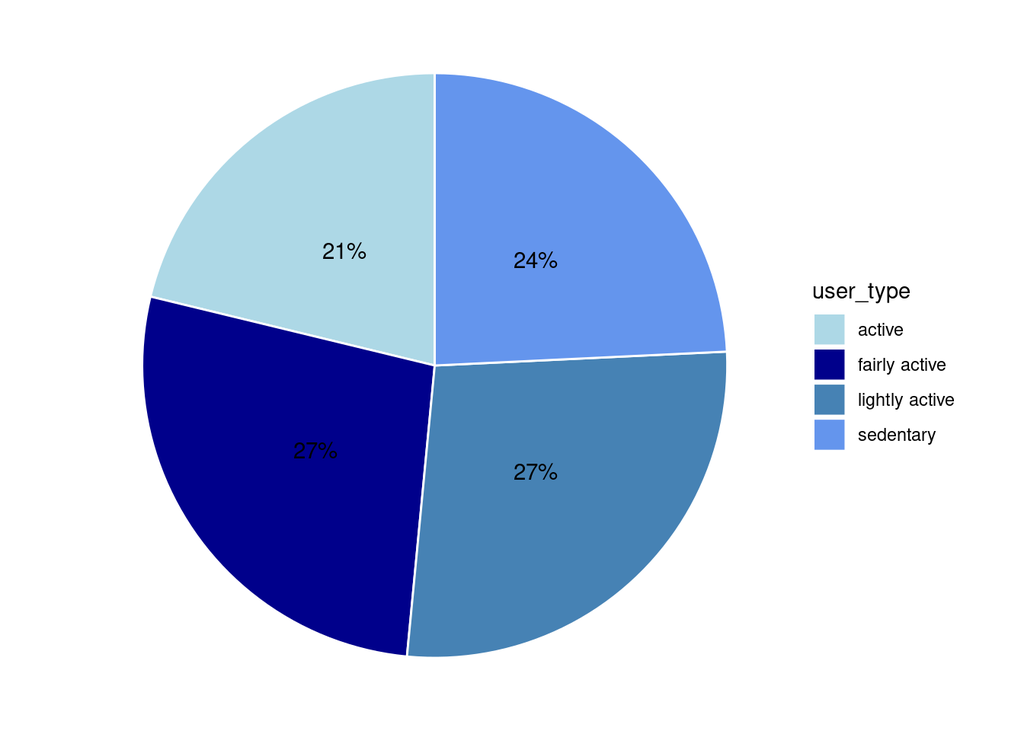

```r
library(dplyr)
library(ggplot2)

# create blue color scale
colors <- c("lightblue", "darkblue", "steelblue", "cornflowerblue", "navyblue")

# create pie chart with different colors for each user type
ggplot(user_activity_perc, aes(x = "", y = percentage, fill = user_type)) +
  geom_bar(width = 1, stat = "identity", color = "white") +
  geom_text(aes(label = paste0(round(percentage), "%")), position = position_stack(vjust = 0.5)) +
  coord_polar(theta = "y") +
  scale_fill_manual(values = colors) +
  theme_void()
```

### *We now want to explore when users are most physically active during the day.*

```r
Hourly_intensities$ActivityHour=as.POSIXct(Hourly_intensities$ActivityHour, format="%m/%d/%Y %I:%M:%S %p", tz=Sys.timezone())
Hourly_intensities$time <- format(Hourly_intensities$ActivityHour, format = "%H:%M:%S")
Hourly_intensities$date <- format(Hourly_intensities$ActivityHour, format = "%m/%d/%y")

head(Hourly_intensities)
```

```
##           Id        ActivityHour TotalIntensity AverageIntensity     time
## 1 1503960366 2016-04-12 00:00:00             20         0.333333 00:00:00
## 2 1503960366 2016-04-12 01:00:00              8         0.133333 01:00:00
## 3 1503960366 2016-04-12 02:00:00              7         0.116667 02:00:00
## 4 1503960366 2016-04-12 03:00:00              0         0.000000 03:00:00
## 5 1503960366 2016-04-12 04:00:00              0         0.000000 04:00:00
## 6 1503960366 2016-04-12 05:00:00              0         0.000000 05:00:00
##       date
## 1 04/12/16
## 2 04/12/16
## 3 04/12/16
## 4 04/12/16
## 5 04/12/16
## 6 04/12/16
```

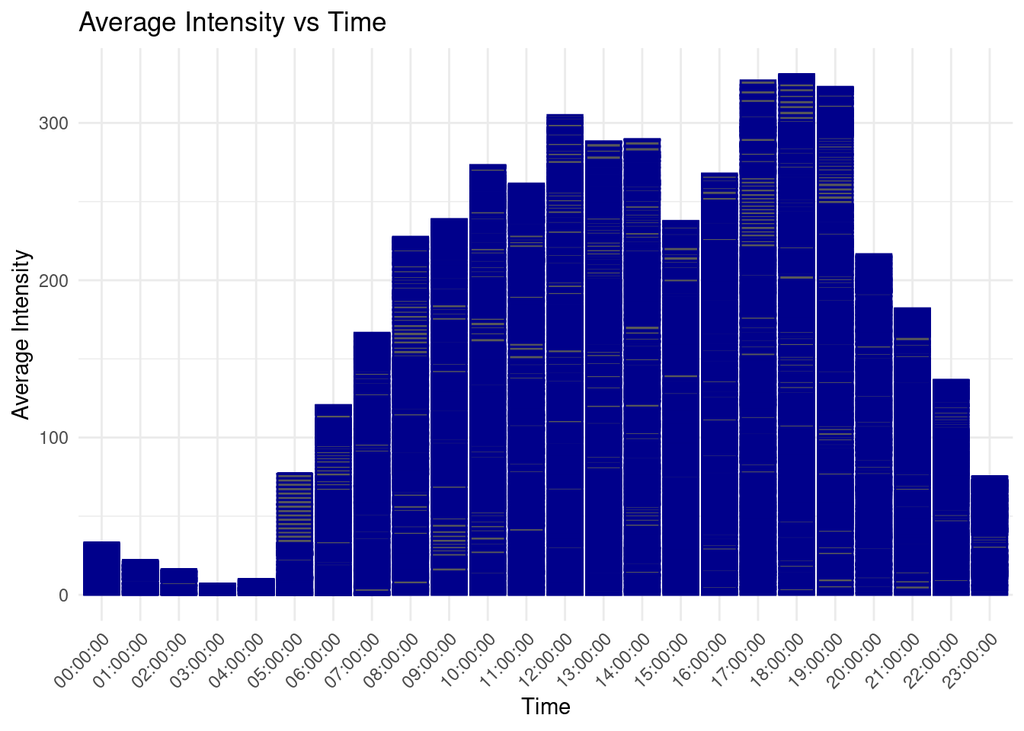

```r
# Create a histogram of intensity
ggplot(Hourly_intensities, aes(x = time, y = AverageIntensity)) +
  geom_histogram(stat = "identity", color = "darkblue") +
  labs(x = "Time", y = "Average Intensity", fill = "Intensity") +
  ggtitle("Average Intensity vs Time ") +
  theme_minimal() +
  theme(axis.text.x = element_text(angle = 45, hjust = 1))
```

The graph above reveals a notable trend where users *exhibit higher activity levels between 17:00h and 19:00h.* To promote increased physical activity among Bellabeat users, the team could *consider sending reminders to encourage running or walking during this specific time frame.*

## Act

Based on everything we have seen before, some **key findings** are:

- **Our users are on the lower band of both steps/day and hours slept per day. It would be highly advisable to increase these two parameters to promoto a healthy lifestyle for users.*
- **There is a correlation observed between the daily steps taken and the calories burned, as well as between the total time spent in bed and minutes asleep.**
- **The majority of users (51%) are not very active physically.**
- **Users are most active between 17.00 to 19.00h.**